# R Notebook

```r
library(rpart)
library(rpart.plot)
library(tidyverse)
```

```r
library(tidyverse)
titanic_set <- read_csv('titanic_decision_tree_data.csv')
```

```r
shuffle_index <- sample(1:nrow(titanic_set))
```

```r
# shuffle the data so class order isn't in order - need this for training/testing split later on
titanic_set <- titanic_set[shuffle_index, ]
```

```r
titanic_set
```

| X1 | passenger_id | pclass | name | sex | age | sib_sp | parch | ticket | fare | cabin | embarked | survived |
| --- | --- | --- | --- | --- | --- | --- | --- | --- | --- | --- | --- | --- |
| 1170 | 752 | 3 | Moor, Master. Meier | male | 6.00 | 0 | 1 | 392096 | 12.4750 | E121 | S | 1 |
| 670 | 252 | 3 | Strom, Mrs. Wilhelm (Elna Matilda Persson) | female | 29.00 | 1 | 1 | 347054 | 10.4625 | G6 | S | 0 |
| 757 | 339 | 3 | Dahl, Mr. Karl Edwart | male | 45.00 | 0 | 0 | 7598 | 8.0500 | NA | S | 1 |
| 742 | 324 | 2 | Caldwell, Mrs. Albert Francis (Sylvia Mae Harbaugh) | female | 22.00 | 1 | 1 | 248738 | 29.0000 | NA | S | 1 |
| 827 | 409 | 3 | Birkeland, Mr. Hans Martin Monsen | male | 21.00 | 0 | 0 | 312992 | 7.7750 | NA | S | 0 |
| 536 | 118 | 2 | Turpin, Mr. William John Robert | male | 29.00 | 1 | 0 | 11668 | 21.0000 | NA | S | 0 |
| 959 | 541 | 1 | Crosby, Miss. Harriet R | female | 36.00 | 0 | 2 | WE/P 5735 | 71.0000 | B22 | S | 1 |
| 498 | 80 | 3 | Dowdell, Miss. Elizabeth | female | 30.00 | 0 | 0 | 364516 | 12.4750 | NA | S | 1 |
| 119 | 1010 | 1 | Beattie, Mr. Thomson | male | 36.00 | 0 | 0 | 13050 | 75.2417 | C6 | C | NA |
| 294 | 1185 | 1 | Dodge, Dr. Washington | male | 53.00 | 1 | 1 | 33638 | 81.8583 | A34 | S | NA |

[output cut: 990 more lines]

1.1 Question 1

Cleaning up the data is always the first step. Do the following: Take only observations which have a survived flag (i.e. that aren’t missing) Turn your important variables into factors (sex, survived, pclass, embarkation) - Convert to factor Create an age_status variable which groups individuals under (and including) 16 years of age into a category called “child” category and those over 16 into a category called “adult”. Drop the NA Drop any variables you don’t need (X1, passenger_id, name, ticket, far, cabin)

```r
titanic_clean <- titanic_set %>%
  # filter(survived %in% c(0,1)) %>%
    mutate(sex = as.factor(sex),
           age_status = as.factor(if_else(age <= 16, "child", "adult")),
         class = factor(pclass, levels = c(3,2,1), labels = c("Lower", "Middle", "Upper")),
           survived_flag = factor(survived, levels = c(0,1), labels = c("No", "Yes")),
           port_embarkation = as.factor(embarked)) %>%
  select(sex, age_status, class, port_embarkation, sib_sp, parch, survived_flag) %>%
  na.omit()
titanic_clean
```

| sex | age_status | class | port_embarkation | sib_sp | parch | survived_flag |
| --- | --- | --- | --- | --- | --- | --- |
| male | child | Lower | S | 0 | 1 | Yes |
| female | adult | Lower | S | 1 | 1 | No |
| male | adult | Lower | S | 0 | 0 | Yes |
| female | adult | Middle | S | 1 | 1 | Yes |
| male | adult | Lower | S | 0 | 0 | No |
| male | adult | Middle | S | 1 | 0 | No |
| female | adult | Upper | S | 0 | 2 | Yes |
| female | adult | Lower | S | 0 | 0 | Yes |
| male | adult | Middle | S | 0 | 0 | No |
| female | child | Lower | C | 1 | 1 | No |

[output cut: 702 more lines]

1.2 Question 2

Have a look at your data and create some plots to ensure you know what you’re working with before you begin. Write a summary of what you have found in your plots. Which variables do you think might be useful to predict whether or not people are going to die? Knowing this before you start is the best way to have a sanity check that your model is doing a good job

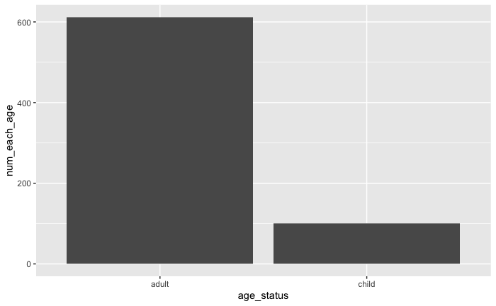

```r
titanic_clean %>%
  group_by(age_status) %>%
  summarise(num_each_age = n()) %>%
  ggplot(aes(x = age_status, y = num_each_age)) +
  geom_col()
```

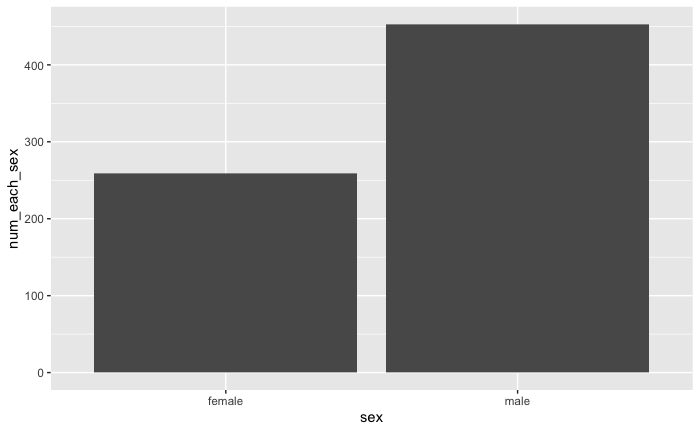

```r
titanic_clean %>%
  group_by(sex) %>%
  summarise(num_each_sex = n()) %>%
  ggplot(aes(x = sex, y = num_each_sex)) +
  geom_col()
```

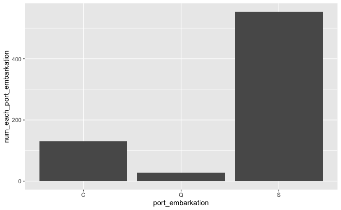

```r
titanic_clean %>%
  group_by(port_embarkation) %>%
  summarise(num_each_port_embarkation = n()) %>%
  ggplot(aes(x = port_embarkation, y = num_each_port_embarkation)) +
  geom_col()
```

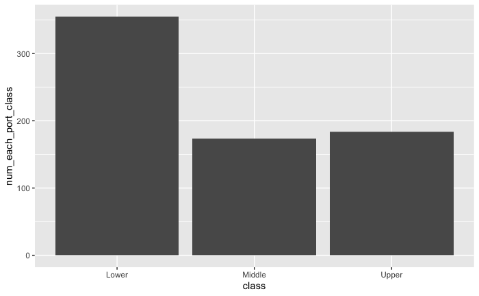

```r
titanic_clean %>%
  group_by(class) %>%
  summarise(num_each_port_class = n()) %>%
  ggplot(aes(x = class, y = num_each_port_class)) +
  geom_col()
```

1.3 Question 3 Now you can start to build your model. Create your testing and training set using an appropriate split. Check you have balanced sets. Write down why you chose the split you did and produce output tables to show whether or not it is balanced.

# train test split

```r
n_data <- nrow(titanic_clean)

# get an index
test_index <- sample(1:n_data, size = n_data*0.2)

# get those rows from the actual index
titanic_test <- slice(titanic_clean, test_index)

#get the training dataset
titanic_train <- slice(titanic_clean, -test_index)
```

```r
library(janitor)
```

```r
titanic_test %>%
  tabyl(class)
```

```
  class  n   percent
  Lower 74 0.5211268
 Middle 24 0.1690141
  Upper 44 0.3098592
```

```r
titanic_train %>%
  tabyl(class)
```

```
  class   n   percent
  Lower 281 0.4929825
 Middle 149 0.2614035
  Upper 140 0.2456140
```

```r
titanic_fit <- rpart(class ~ . ,
                    data = titanic_train,
                    method = "class")
titanic_fit
```

```
n= 570

node), split, n, loss, yval, (yprob)
      * denotes terminal node

 1) root 570 289 Lower (0.49298246 0.26140351 0.24561404)
   2) survived_flag=No 346 130 Lower (0.62427746 0.22254335 0.15317919) *
   3) survived_flag=Yes 224 137 Upper (0.29017857 0.32142857 0.38839286)
     6) port_embarkation=Q,S 164  99 Middle (0.32926829 0.39634146 0.27439024)
      12) sex=male 56  31 Lower (0.44642857 0.23214286 0.32142857) *
      13) sex=female 108  56 Middle (0.26851852 0.48148148 0.25000000) *
     7) port_embarkation=C 60  18 Upper (0.18333333 0.11666667 0.70000000)
      14) age_status=child 9   4 Lower (0.55555556 0.33333333 0.11111111) *
      15) age_status=adult 51  10 Upper (0.11764706 0.07843137 0.80392157) *
```

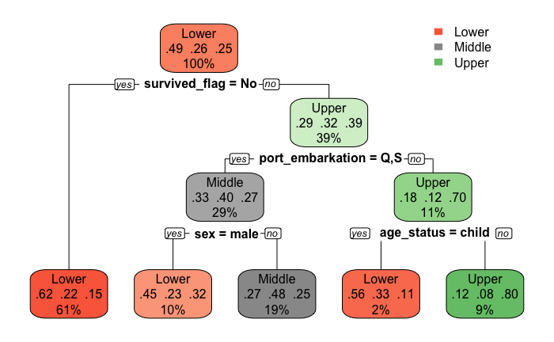

```r
rpart.plot(titanic_fit, yesno = 2)
```

1.4 Question 5

1.5 Question 6 Test and add your predicitons to your data. Create a confusion matrix. Write down in detial what this tells you for this specific dataset.

```r
library(modelr)
```

```r
titanic_test_pred <- titanic_test %>%
  add_predictions(titanic_fit, type = "class")
titanic_test_pred
```

| sex | age_status | class | port_embarkation | sib_sp | parch | survived_flag | pred |
| --- | --- | --- | --- | --- | --- | --- | --- |
| male | child | Lower | S | 1 | 2 | Yes | Lower |
| male | child | Upper | S | 0 | 2 | Yes | Lower |
| female | child | Lower | C | 1 | 0 | Yes | Lower |
| male | adult | Upper | S | 1 | 0 | No | Lower |
| male | adult | Upper | C | 0 | 0 | Yes | Upper |
| male | adult | Lower | S | 0 | 0 | No | Lower |
| male | adult | Middle | S | 0 | 0 | No | Lower |
| male | adult | Middle | S | 0 | 0 | No | Lower |
| male | adult | Middle | S | 0 | 0 | No | Lower |
| male | adult | Upper | S | 1 | 1 | Yes | Lower |

[output cut: 132 more lines]

```r
rpart.predict(titanic_fit, newdata = titanic_test[1:3, ], rules = FALSE)
```

```
      Lower    Middle     Upper
1 0.4464286 0.2321429 0.3214286
2 0.4464286 0.2321429 0.3214286
3 0.5555556 0.3333333 0.1111111
```

```r
library(yardstick)
```

```r
conf_matrix <- titanic_test_pred %>%
  conf_mat(truth = class, estimate = pred)
conf_matrix
```

```
          Truth
Prediction Lower Middle Upper
    Lower     66     14    17
    Middle     7      9    16
    Upper      1      1    11
```

```r
accuracy_deaths <- titanic_test_pred %>%
  accuracy(truth = class, estimate = pred)
accuracy_deaths
```

| .metric | .estimator | .estimate |
| --- | --- | --- |
| accuracy | multiclass | 0.6056338 |